# Multilinear Regression

## Computing a New Model

In theory, larger values for `drat` should result to higher fuel consumption, i.e., lower `mpg`. Inversely, smaller values for `drat` should result to higher `mpg`. However, in our previous model the case was inverted since the regression coefficient was `1.615049` which is positive, that is, `drat` is found to positively affect `mpg`. One way to verify this is to also plot a correlogram including `mpg`, so:

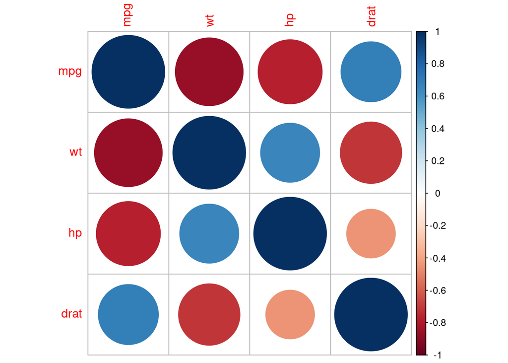

```r
corrplot(cor(mtcars[, c('mpg', 'wt', 'hp', 'drat')]), method = 'circle')
```

We are now going to create a compound index taking into account `drat` and `hp` together by multiplying those, i.e.:

```r
cor_mlm <- lm(formula = mpg ~ wt + hp + drat + hp * drat, data = mtcars)
summary(cor_mlm)
```

```
##
## Call:
## lm(formula = mpg ~ wt + hp + drat + hp * drat, data = mtcars)
##
## Residuals:
##     Min      1Q  Median      3Q     Max
## -3.2292 -1.8974 -0.7182  0.9502  5.3868
##
## Coefficients:
##             Estimate Std. Error t value Pr(>|t|)
## (Intercept) 17.13334    8.98518   1.907 0.067234 .
## wt          -3.59247    0.79164  -4.538 0.000105 ***
## hp           0.07517    0.05983   1.256 0.219741
## drat         5.02313    2.21859   2.264 0.031810 *
## hp:drat     -0.02849    0.01571  -1.814 0.080835 .
## ---
## Signif. codes:  0 '***' 0.001 '**' 0.01 '*' 0.05 '.' 0.1 ' ' 1
##
## Residual standard error: 2.463 on 27 degrees of freedom
## Multiple R-squared:  0.8546, Adjusted R-squared:  0.8331
## F-statistic: 39.67 on 4 and 27 DF,  p-value: 6.208e-11
```

Above we added an interaction term, as we say, where we add, alongside `drat` and `hp`, also `hp*drat`, i.e., their product. This is typically done in cases where we are interested into quantifying any interaction between two or more of our independent variables. However, we should do so carefully, because adding such terms typically lowers the significance of other variables’ coefficients, as we saw above. If that happens, this means that doing so actually introduced more multicollinearity, i.e., made our model worse. So, this interaction, should, in principle, be ignored.

Maybe, a different approach, might be to just drop `drat`, to begin with, and see with what sort of model we end up with:

```r
no_drat_mlm <- lm(formula = mpg ~ wt + hp, data = mtcars)
summary(no_drat_mlm)
```

```
##
## Call:
## lm(formula = mpg ~ wt + hp, data = mtcars)
##
## Residuals:
##    Min     1Q Median     3Q    Max
## -3.941 -1.600 -0.182  1.050  5.854
##
## Coefficients:
##             Estimate Std. Error t value Pr(>|t|)
## (Intercept) 37.22727    1.59879  23.285  < 2e-16 ***
## wt          -3.87783    0.63273  -6.129 1.12e-06 ***
## hp          -0.03177    0.00903  -3.519  0.00145 **
## ---
## Signif. codes:  0 '***' 0.001 '**' 0.01 '*' 0.05 '.' 0.1 ' ' 1
##
## Residual standard error: 2.593 on 29 degrees of freedom
## Multiple R-squared:  0.8268, Adjusted R-squared:  0.8148
## F-statistic: 69.21 on 2 and 29 DF,  p-value: 9.109e-12
```

Now, besides $p$ values and $R^2$, we should also look at Normal Q-Q plots and the rest of the useful plots we saw last time:

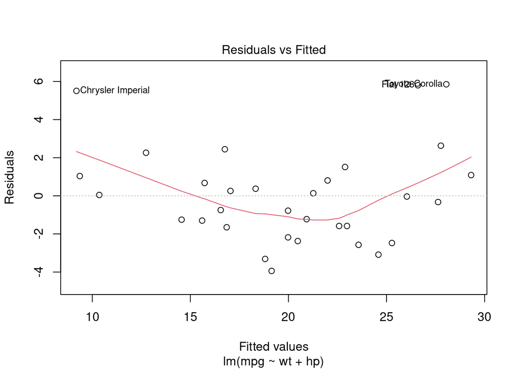

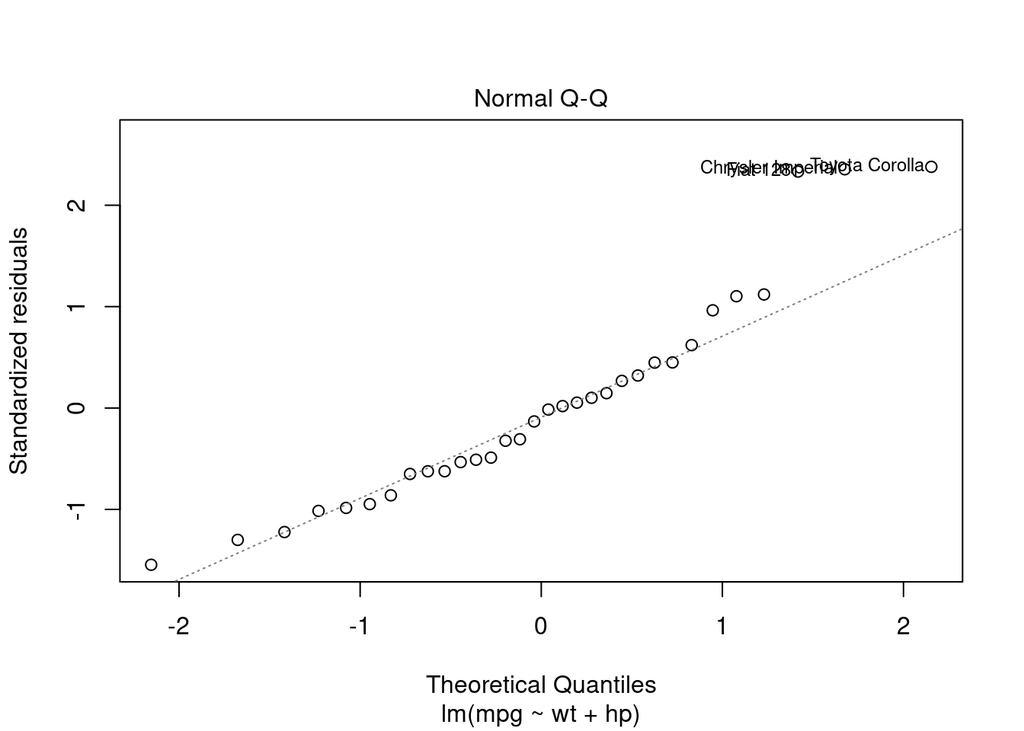

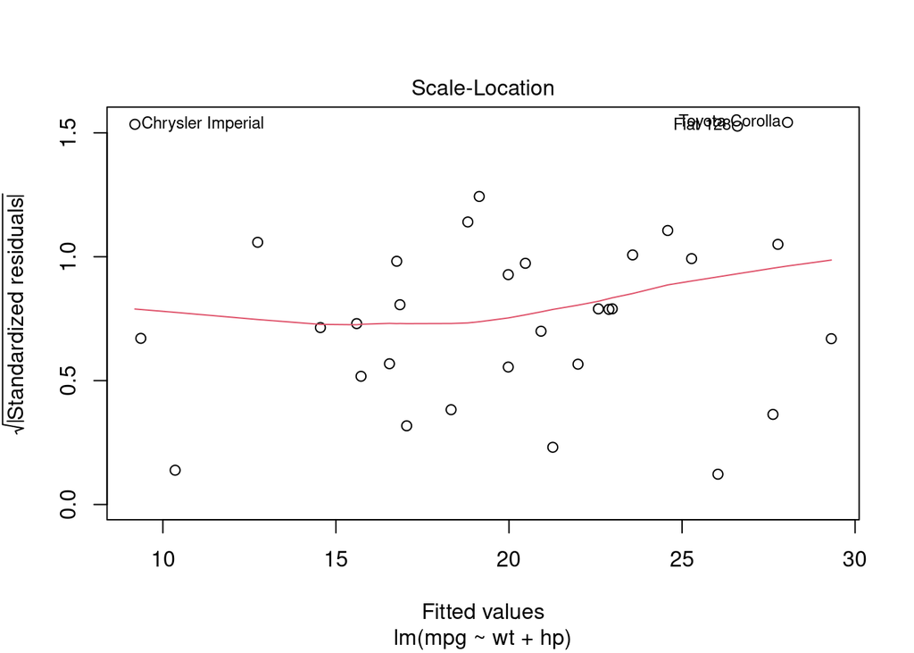

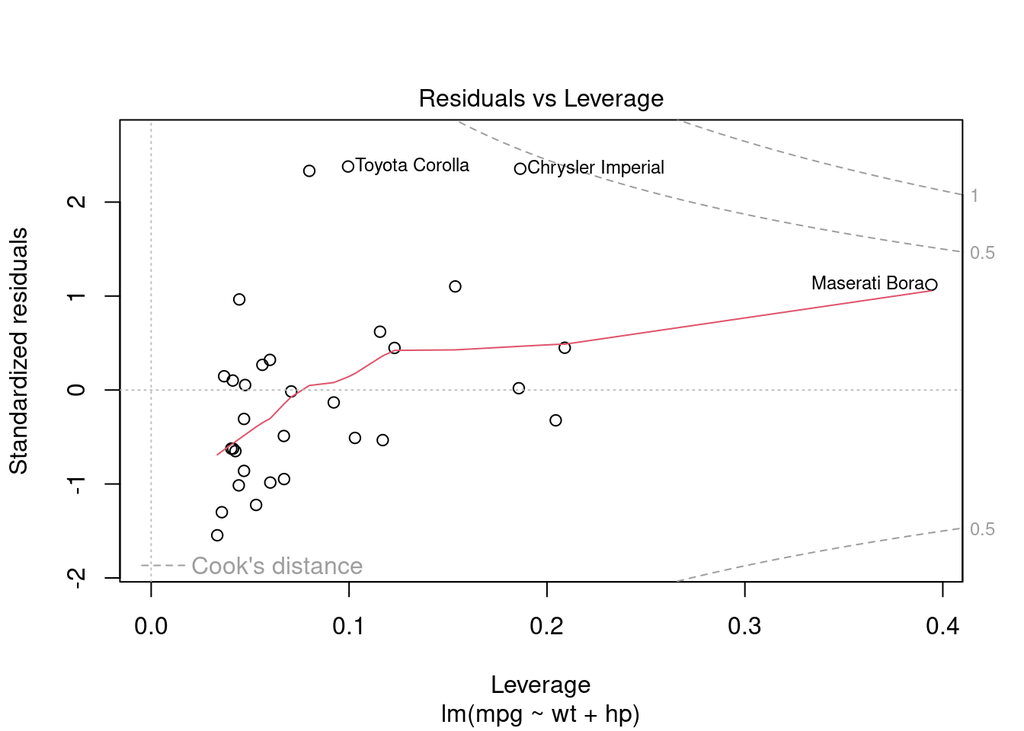

```r
plot(no_drat_mlm)
```

## Trying A Different Approach

Another approach to handle correlations between variables is to create a new variable based on highly correlated ones and create a simpler model. In our case, out of `wt`, `hp` and `drat`, we saw that `drat` is maybe irrelevant to `mpg` on the presence of the others, so we dropped it. Also, we saw that `wt` and `hp` are quite positively correlated, so, we might create a new index by using both `wt` and `hp` and then use that to create a simple regression model. One simple approach is to center our values for `wt` and `hp` by subtracting their mean values and then add them, i.e.:

```r
mwt <- mean(mtcars$wt)
mhp <- mean(mtcars$hp)
wt_hp_index <- (mtcars$wt - mwt + mtcars$hp - mhp)/2
index_data <- data.frame(mtcars$mpg, wt_hp_index)
colnames(index_data) <- c('mpg', 'wt_hp_index')
wt_hp_mlm <- lm(mpg ~ wt_hp_index, data = index_data)
summary(wt_hp_mlm)
```

```
##
## Call:
## lm(formula = mpg ~ wt_hp_index, data = index_data)
##
## Residuals:
##     Min      1Q  Median      3Q     Max
## -5.5857 -2.1380 -0.9074  1.5370  8.1586
##
## Coefficients:
##             Estimate Std. Error t value Pr(>|t|)
## (Intercept) 20.09062    0.67617  29.712  < 2e-16 ***
## wt_hp_index -0.13605    0.01985  -6.853 1.32e-07 ***
## ---
## Signif. codes:  0 '***' 0.001 '**' 0.01 '*' 0.05 '.' 0.1 ' ' 1
##
## Residual standard error: 3.825 on 30 degrees of freedom
## Multiple R-squared:  0.6102, Adjusted R-squared:  0.5972
## F-statistic: 46.97 on 1 and 30 DF,  p-value: 1.322e-07
```

Here, we get a solid $p$ value, but our model explains much less of the variance. To see that, we can also plot the corresponding scatterplot:

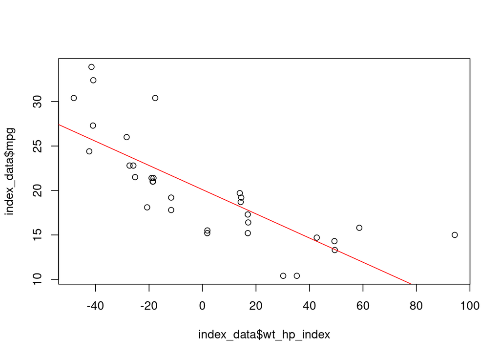

```r
plot(index_data$wt_hp_index, index_data$mpg)
abline(wt_hp_mlm, col = 'red')
```

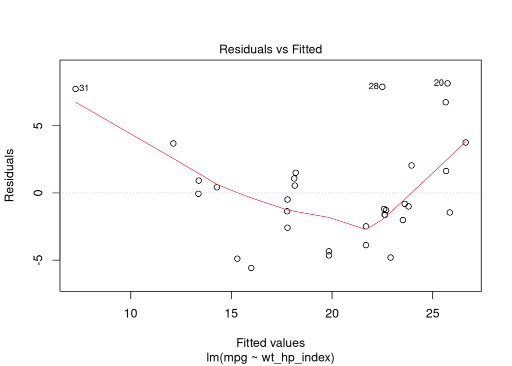

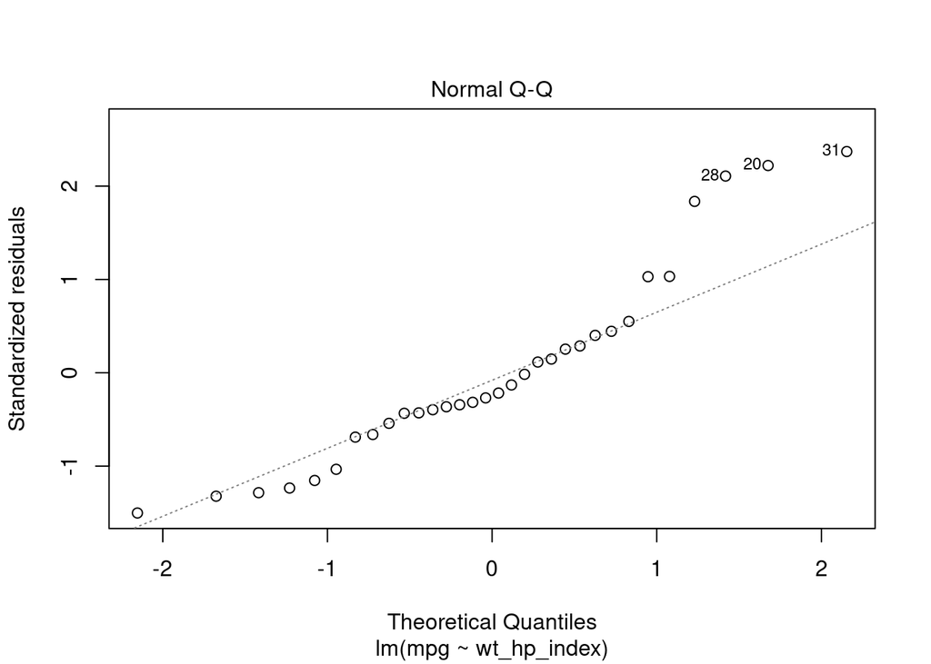

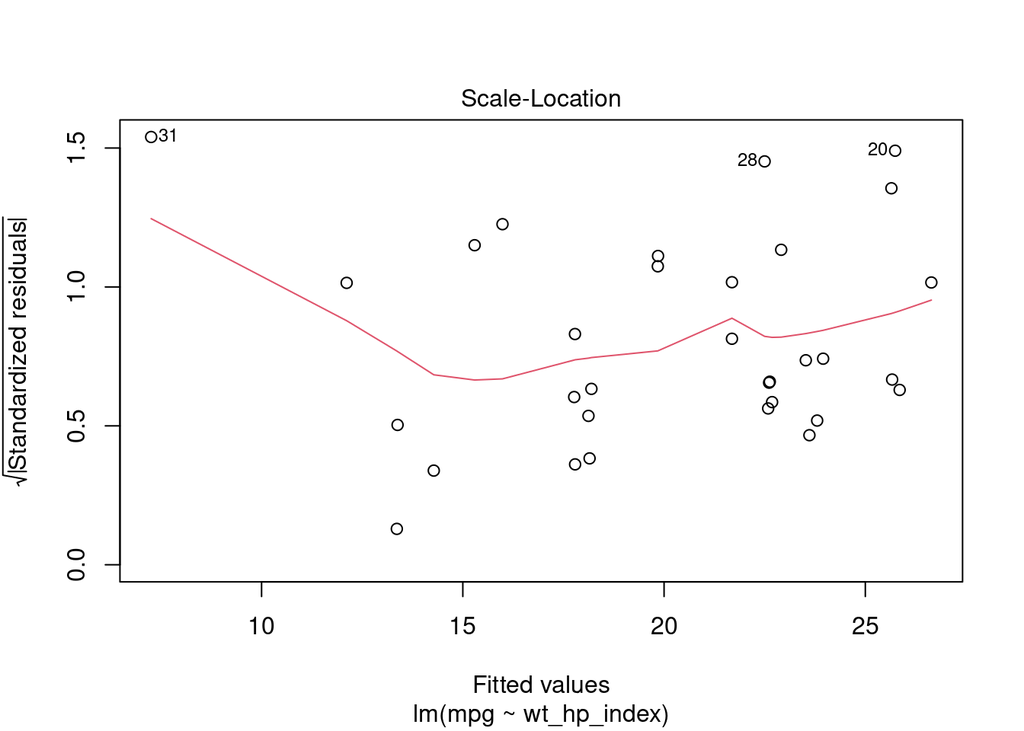

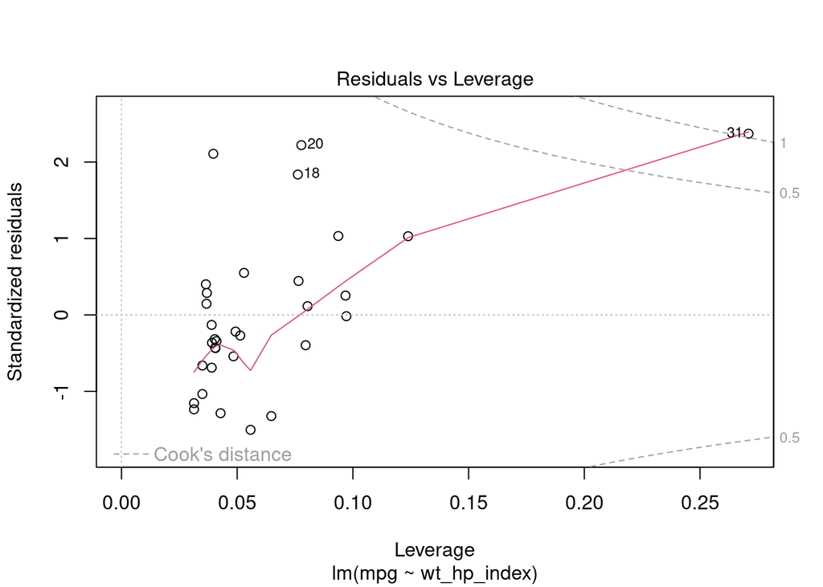

```r
plot(wt_hp_mlm)
```

So, for this model, we see that all metrics discussed above are more or less worse off than in the first and third models. Evidently, we should keep either the simple `mpg ~ wt` model or the multilinear `mpg ~ wt + hp` models, which do explain a lot of variance with most metrics being quite good.

# Working with Real Data

Let us now briefly try to create some models on real data, in particular, the ESS-pol dataset we had extracted last time.

```r
ess_pol <- read.csv('ess_pol.csv', header = TRUE, sep = ',')
head(ess_pol)
```

```
##   X ess_data.cntry ess_data.nwspol ess_data.netusoft ess_data.netustm
## 1 1             AT              90                 5              180
## 2 2             AT              90                 5              570
## 3 3             AT              30                 5               30
## 4 4             AT              15                 1             6666
## 5 5             AT              60                 5              120
## 6 6             AT             120                 5              120
##   ess_data.ppltrst
## 1                5
## 2               10
## 3                6
## 4                6
## 5                6
## 6                8
```

To begin with, we should clean all dummy values, i.e., 7777, 8888, 9999 and so on:

```r
# We essentially look through each row, compute the sum of those that contain 9999 and keep only those which
# sum up to 0, i.e., those that do not contain 9999
for (v in c(5555, 6666, 7777, 8888, 9999)) {
  ess_pol <- ess_pol[rowSums(ess_pol == v, na.rm = TRUE) == 0, ]
}
```

Next, we create a simple MLM:

```r
ess_lm <- lm(formula = ess_data.ppltrst ~ ess_data.nwspol + ess_data.netusoft + ess_data.netustm, data = ess_pol)
summary(ess_lm)
```

```
##
## Call:
## lm(formula = ess_data.ppltrst ~ ess_data.nwspol + ess_data.netusoft +
##     ess_data.netustm, data = ess_pol)
##
## Residuals:
##    Min     1Q Median     3Q    Max
## -5.719 -1.477 -0.305  1.654 93.890
##
## Coefficients:
##                     Estimate Std. Error t value Pr(>|t|)
## (Intercept)        4.1981335  0.3701901  11.340  < 2e-16 ***
## ess_data.nwspol   -0.0002429  0.0001452  -1.672  0.09444 .
## ess_data.netusoft  0.2238868  0.0760692   2.943  0.00325 **
## ess_data.netustm   0.0002787  0.0001214   2.295  0.02174 *
## ---
## Signif. codes:  0 '***' 0.001 '**' 0.01 '*' 0.05 '.' 0.1 ' ' 1
##
## Residual standard error: 4.395 on 38481 degrees of freedom
## Multiple R-squared:  0.000514,   Adjusted R-squared:  0.0004361
## F-statistic: 6.597 on 3 and 38481 DF,  p-value: 0.0001881
```

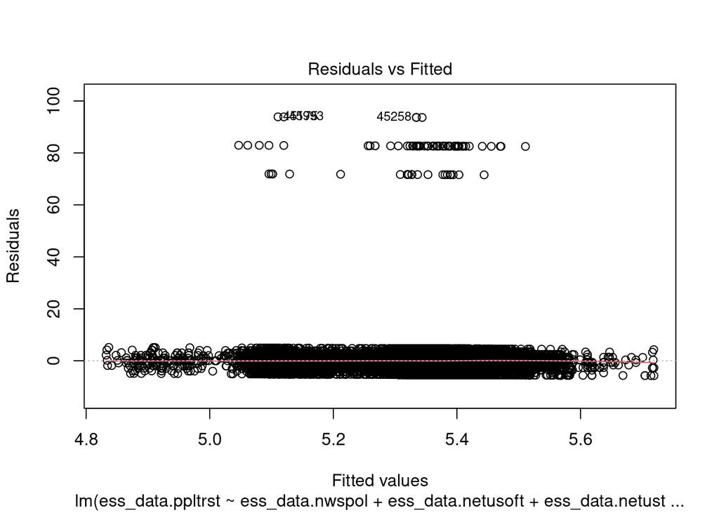

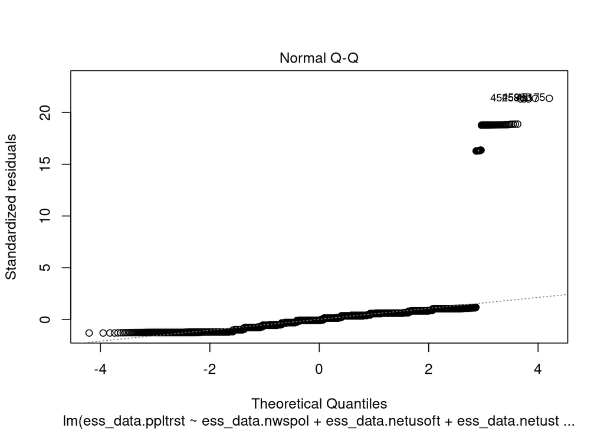

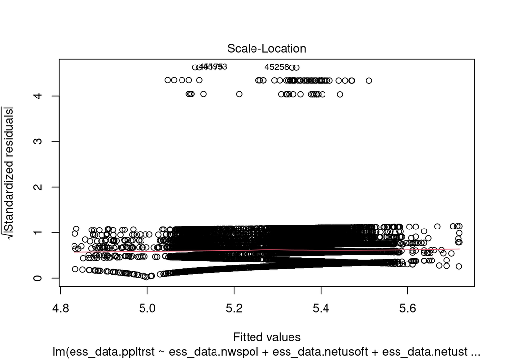

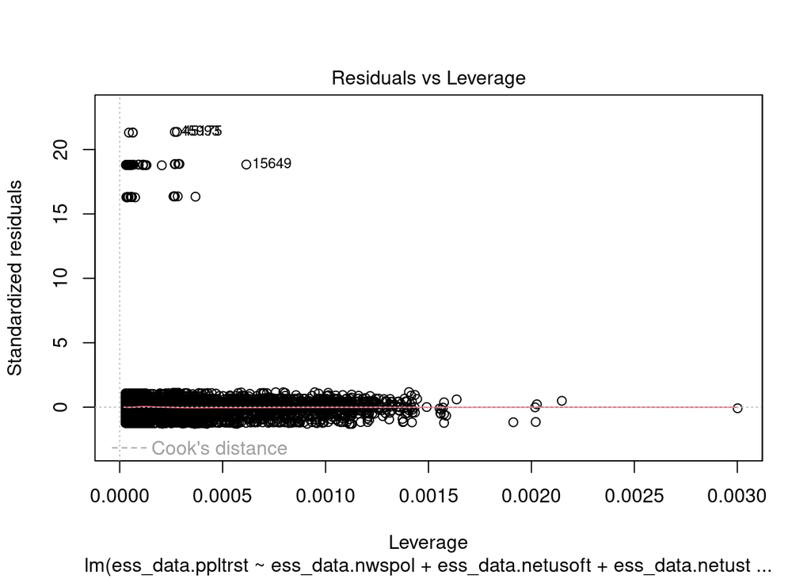

```r
plot(ess_lm)
```

This is evidently a bad model, mostly because we have not taken into account country plus some further data cleaning is required. So, you can have fun yourselves if you want to.